# Practica4

178095: Dorely Morales Santiago

11/7/2019

## Practica 4 Probabilidad: 1 Elementos de Probabilidad

Lanzamiento de una moneda cargada Supóngase que $P(\{\text{sol}\}) = .7$ y $P(\{\text{águila}\}) = .3$ entonces:

```r
probspace(tosscoin(1), probs = c(0.70, 0.30))
```

```
##   toss1 probs
## 1     H   0.7
## 2     T   0.3
```

Ejercicio: ¿cómo calcular la probabilidad anterior con la función urnsamples?

```r
probas<-probspace(urnsamples(1:2, size = 1),probs=c(0.7,0.3))
probas$out<- c("H", "T")
probas
```

```
##   out probs
## 1   H   0.7
## 2   T   0.3
```

## Practica 4 Probabilidad: 7 Variables aleatorias

Los siguientes ejercicios realizarlos en R y con ggplot2:

5. Encontrar los histogramas de probabilidad para las distribuciones asociadas a las siguientes variables aleatorias:
1. El número de águilas que aparecen cuando lanzamos tres monedas al aire.

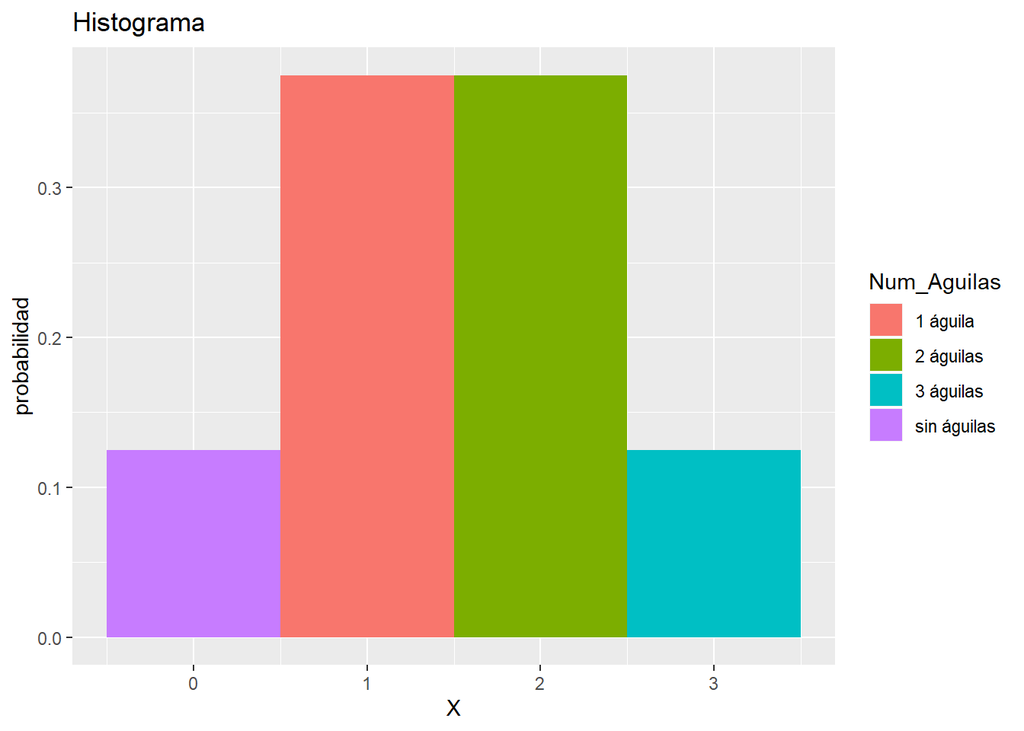

```r
a0<-dbinom(0,3,.5)
a1<-dbinom(1,3,.5)
a2<-dbinom(2,3,.5)
a3<-dbinom(3,3,.5)

df = data.frame(Num_Aguilas = c('sin águilas', '1 águila', '2 águilas', '3 águilas'), X = c(0,1,2,3), probabilidad=c(a0,a1,a2,a3))

ggplot(data = df, aes(x=X, y=probabilidad, fill=Num_Aguilas)) +
geom_col(width=1) + #con el '+' añadimos capas a la gráfica
ggtitle('Histograma') #aes nos ayuda a mapear variables a objetos en la gráfica
```

2. La suma de los números de las caras cuando se lanzan dos dados.

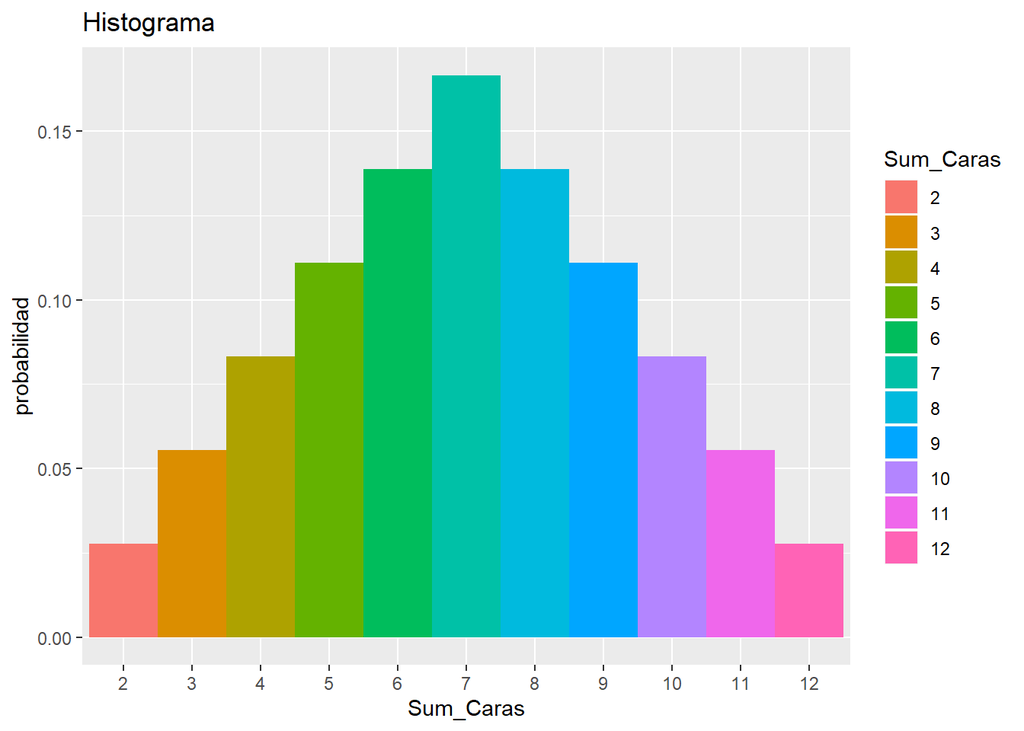

```r
S <- rolldie(2, nsides = 6, makespace = TRUE) #lanzamiento de un dado dos veces.
S <- addrv(S, U = X1+X2)
sumas<-marginal(S,vars = "U")

df = data.frame(Sum_Caras = factor(sumas$U), probabilidad=sumas$probs)
ggplot(data = df, aes(x=Sum_Caras, y=probabilidad, fill=Sum_Caras)) +
geom_col(width=1) + #con el '+' añadimos capas a la gráfica
ggtitle('Histograma') #aes nos ayuda a mapear variables a objetos en la gráfica
```

6. Se venden 8000 boletos para una rifa de $\$5000.00$ y cada boleto cuesta $\$2.00$.
1. Encontrar la ganancia esperada del comprador de un boleto.

```r
n=8000
premio=5000
costbol=2
gec=((1/n)*(premio-costbol))+((1-(1/n))*-costbol)
#La ganancia esperada es de:
gec
```

```
## [1] -1.375
```

2. Hacer la gráfica de la ganancia esperada que tiene una compradora en términos de un número de boletos $n$.

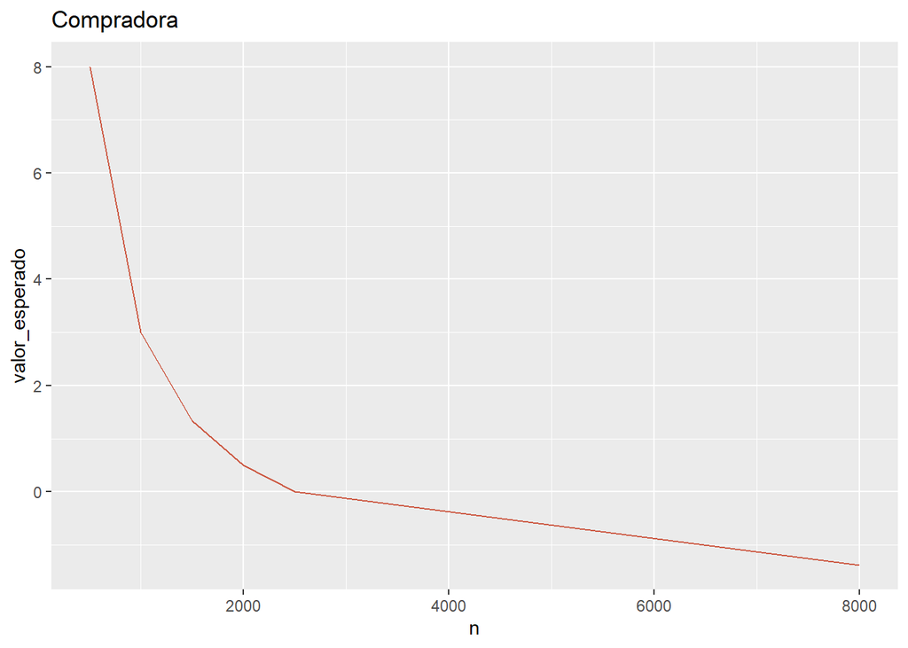

```r
df_compradora <- data.frame(n=c(500,1000,1500,2000,2500,8000), valor_esperado=c(8,3,1.333,.5,0,-1.375))
ggplot(data=df_compradora, aes(x=n, y=valor_esperado)) +
geom_line(colour='coral3') +
ggtitle('Compradora')
```

3. ¿Cuál debería de ser el premio mínimo para que se pudiese garantizar “salir a mano” al comprar todos los boletos.

```r
n=8000
costbol=2
#el valor esperado de la ganancia del comprador se debe igualar a cero y despejar el premio como incógnita de la ecuación:
premio=n*costbol*(1-(1/n))+2
#El premio mínimo debería ser de:
premio
```

```
## [1] 16000
```